# Linear Regression

Gustavo Magaña López

4/26/2020

## Used packages

When working with R, we can define our own functions and create modules called packages which serve a specific purpose. These can be submitted to [CRAN](https://cran.r-project.org/)(The Comprehensive R Archive Network). Publishing a package enables people to use the code you have developed! In this case we are using the following packages:

```r
library(ggplot2)
```

# The regression problem

Imagine that we have a couple of variables which we know to be correlated. There is a variable we control $x$ and the second one $y$ is partially determined by it. There is obviously some noise, some thing that we cannot control in the measurement process or maybe the phenomenon is stochastic in nature.

## Assumptions underlying Simple Linear Regression

1. Values of the independent variable X are said to be fixed.
2. The variable X is measured without error.
3. For each value of X there is a subpopulation of Y values. For the usual inferential procedures of estimation and hypothesis testing to be valid, these subpopulations must be normally distributed.
4. The variances of the subpopulations of Y are all equal and denoted by s2.
5. The means of the subpopulations of Y all lie on the same straight line.This is known as the assumption of linearity.

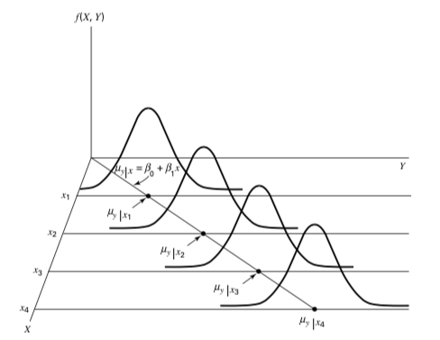

Assumption of linearity

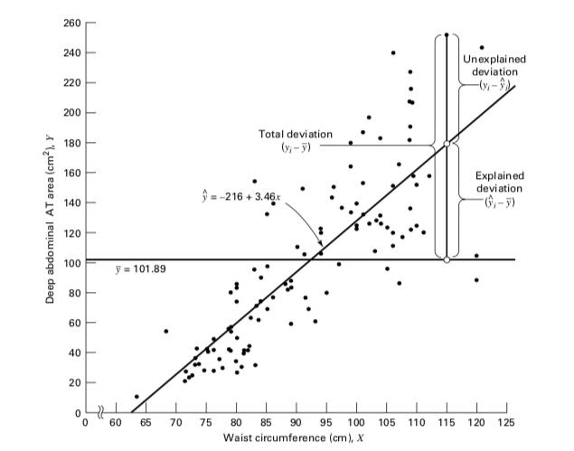

Variations

```r
full.data <- read.csv("../data/sensor_data.csv")
latest <- read.csv("../data/latest2.csv")
```

To see the oldest and latest dates of the full dataset, we take :

```r
full.data$DateTime[1]
```

```
## [1] 2020-03-20 23:45:00
## 8820 Levels: 2020-03-20 23:45:00 2020-03-20 23:50:00 ... 2020-04-23 14:17:00
```

```r
full.data$DateTime[length(full.data$DateTime)]
```

```
## [1] 2020-04-23 14:17:00
## 8820 Levels: 2020-03-20 23:45:00 2020-03-20 23:50:00 ... 2020-04-23 14:17:00
```

Here we only have the latest values

```r
latest$DateTime[1]
```

```
## [1] 2020-04-22 05:02:00
## 400 Levels: 2020-04-22 05:02:00 2020-04-22 05:07:00 ... 2020-04-23 14:17:00
```

```r
latest$DateTime[length(latest$DateTime)]
```

```
## [1] 2020-04-23 14:17:00
## 400 Levels: 2020-04-22 05:02:00 2020-04-22 05:07:00 ... 2020-04-23 14:17:00
```

# Full dataset

### Scatterplot

Here we see all of the data.

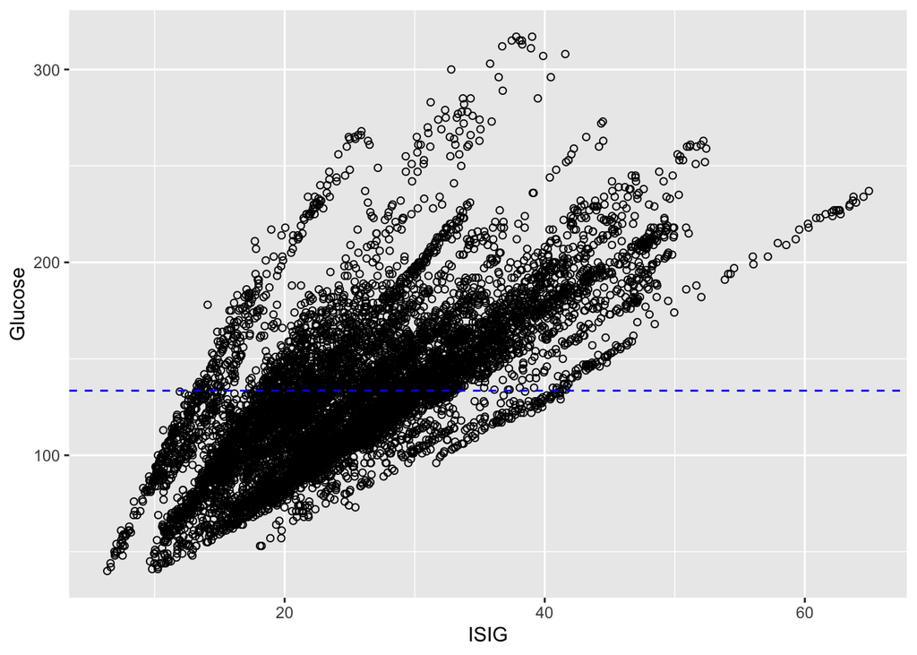

```r
full.data.scatter <- ggplot(data = full.data, aes(x=ISIG, y=Glucose)) +
  geom_point(shape=1) +
  geom_hline(yintercept=mean(full.data$Glucose), linetype="dashed", color = "blue")
print(full.data.scatter)
```

### Regression

```r
full.data.regression <- lm(Glucose ~ ISIG, data = full.data)

summary(full.data.regression)
```

```
##
## Call:
## lm(formula = Glucose ~ ISIG, data = full.data)
##
## Residuals:
##     Min      1Q  Median      3Q     Max
## -59.422 -19.139  -4.183  13.491 145.190
##
## Coefficients:
##             Estimate Std. Error t value Pr(>|t|)
## (Intercept) 51.41543    0.91092   56.44   <2e-16 ***
## ISIG         3.18421    0.03341   95.31   <2e-16 ***
## ---
## Signif. codes:  0 '***' 0.001 '**' 0.01 '*' 0.05 '.' 0.1 ' ' 1
##
## Residual standard error: 27.93 on 8818 degrees of freedom
## Multiple R-squared:  0.5074, Adjusted R-squared:  0.5074
## F-statistic:  9083 on 1 and 8818 DF,  p-value: < 2.2e-16
```

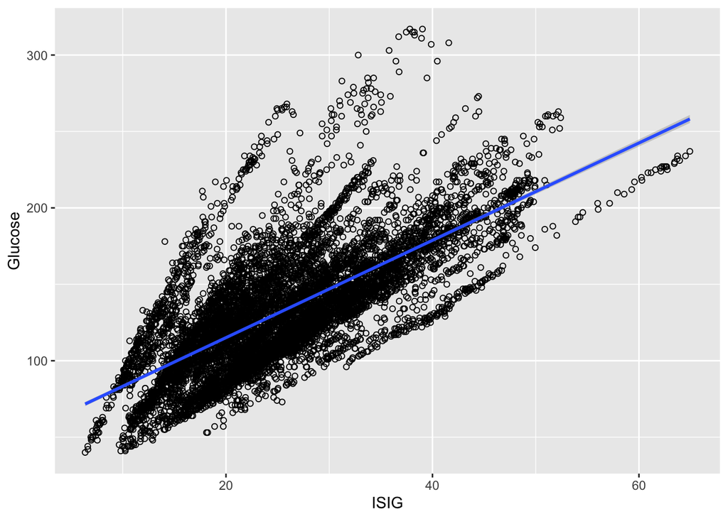

```r
full.data.plot <- ggplot(data = full.data, aes(x=ISIG, y=Glucose)) +
  geom_point(shape=1) +
  geom_smooth(method=lm)   # Add linear regression line

print(full.data.plot)
```

# Latest observations

### Scatterplot

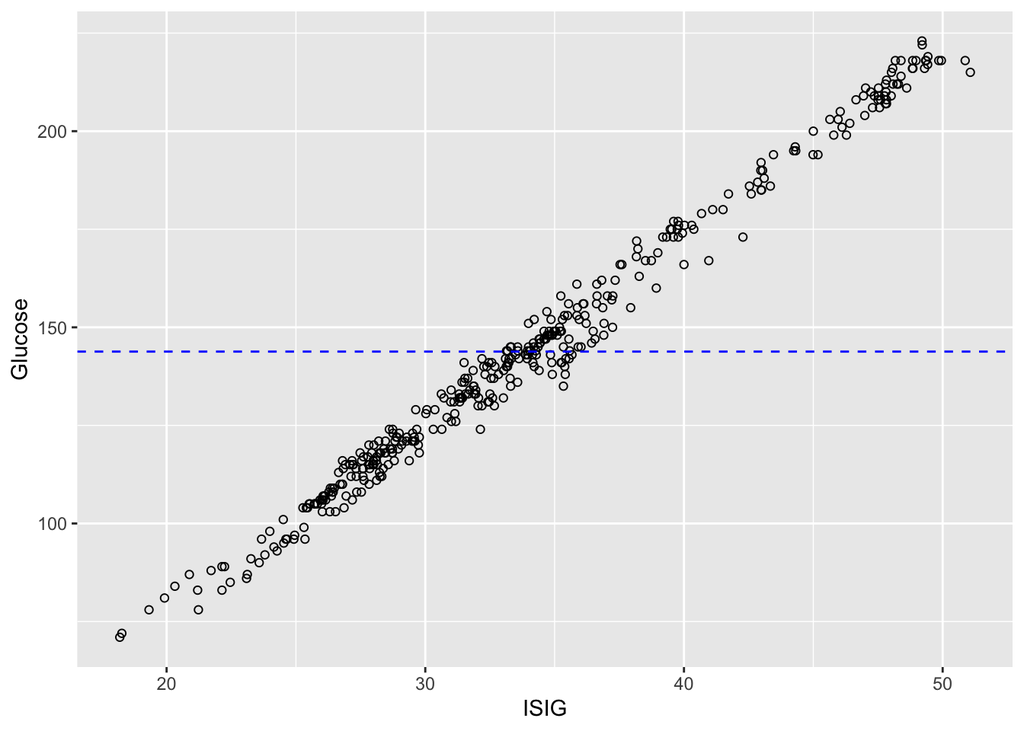

```r
latest.scatter <- ggplot(data = latest, aes(x=ISIG, y=Glucose)) +
  geom_point(shape=1) +
  geom_hline(yintercept=mean(latest$Glucose), linetype="dashed", color = "blue")
print(latest.scatter)
```

### Regression

```r
latest.regression <- lm(Glucose ~ ISIG, data = latest)

summary(latest.regression)
```

```
##
## Call:
## lm(formula = Glucose ~ ISIG, data = latest)
##
## Residuals:
##      Min       1Q   Median       3Q      Max
## -15.2964  -2.0847   0.5692   2.4531   9.0904
##
## Coefficients:
##              Estimate Std. Error t value Pr(>|t|)
## (Intercept) -18.91959    0.92662  -20.42   <2e-16 ***
## ISIG          4.78823    0.02664  179.71   <2e-16 ***
## ---
## Signif. codes:  0 '***' 0.001 '**' 0.01 '*' 0.05 '.' 0.1 ' ' 1
##
## Residual standard error: 3.93 on 398 degrees of freedom
## Multiple R-squared:  0.9878, Adjusted R-squared:  0.9878
## F-statistic: 3.229e+04 on 1 and 398 DF,  p-value: < 2.2e-16
```

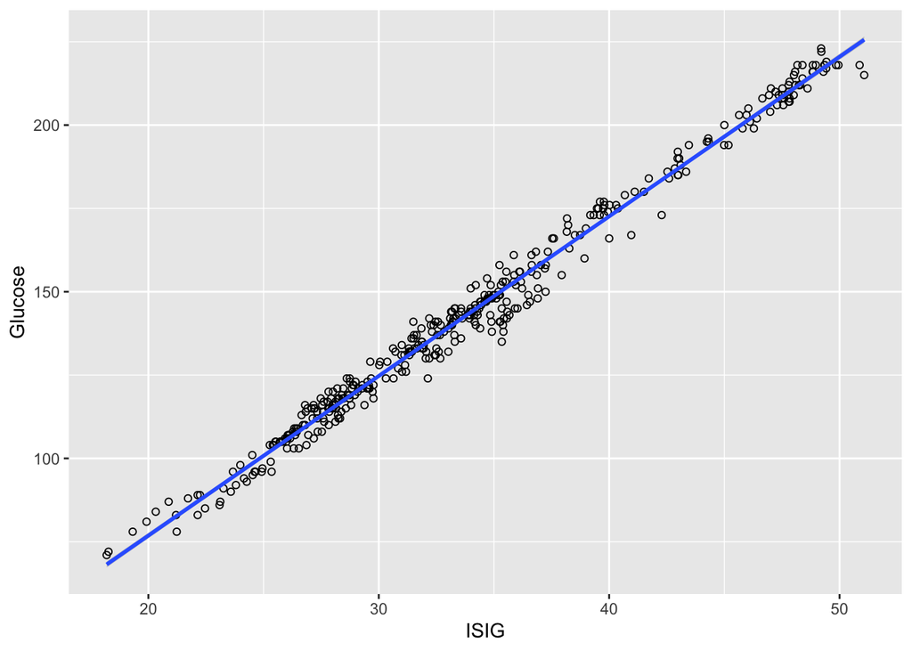

```r
latest.plot <- ggplot(data = latest, aes(x=ISIG, y=Glucose)) +
  geom_point(shape=1) +
  geom_smooth(method=lm)   # Add linear regression line

print(latest.plot)
```